# Tugas Pertemuan 3

Anastasia Salma Irwansyah

2026-09-03

# Persiapan Data

## Packages

```r
library(dLagM)
library(dynlm)
library(MLmetrics)
library(lmtest)
library(car)
```

```r
library(ggplot2)
```

## Impor & Pembagian Data

Data terdiri atas pengamatan per jam selama 3 hari (21-24 Oktober 2022, 72 observasi). Data dibagi menjadi data Training (60 observasi pertama) untuk membentuk model, dan data Testing (12 observasi terakhir, setara 12 jam terakhir) untuk menguji akurasi peramalan.

```r
# Impor Data
data <- read.csv("NewDelhi_Air_quality.csv")
data <- data[order(data$ts), ]
data$Yt <- data$AQI
data$Xt <- data$CO

# Mengecek jumlah data dan membagi data
n        <- nrow(data)
n_test   <- 12
n_train  <- n - n_test

train <- data[1:n_train, ]
test  <- data[(n_train + 1):n, ]

cat("Jumlah observasi total :", n, "\n")
```

```
## Jumlah observasi total : 72
```

```r
cat("Jumlah data training   :", n_train, "\n")
```

```
## Jumlah data training   : 60
```

```r
cat("Jumlah data testing    :", n_test, "\n")
```

```
## Jumlah data testing    : 12
```

```r
cat("Rentang waktu training :", train$timestamp_local[1], "s.d.", train$timestamp_local[n_train], "\n")
```

```
## Rentang waktu training : 2022-10-21T23:00:00 s.d. 2022-10-24T10:00:00
```

```r
cat("Rentang waktu testing  :", test$timestamp_local[1], "s.d.", test$timestamp_local[n_test], "\n")
```

```
## Rentang waktu testing  : 2022-10-24T11:00:00 s.d. 2022-10-24T22:00:00
```

```r
# Mengubah format data menjadi objek Time Series (ts)
train.ts <- ts(train)
test.ts  <- ts(test)
data.ts  <- ts(data)
```

# 1. Model Koyck

## Pemodelan

```r
model.koyck <- koyckDlm(x = train$Xt, y = train$Yt)
summary(model.koyck)
```

```
##
## Call:
## "Y ~ (Intercept) + Y.1 + X.t"
##
## Residuals:
##     Min      1Q  Median      3Q     Max
## -1.9413 -0.8072  0.1443  0.3627  2.2528
##
## Coefficients:
##              Estimate Std. Error t value Pr(>|t|)
## (Intercept)  1.694490  10.020652   0.169    0.866
## Y.1          0.957206   0.085573  11.186 6.74e-16 ***
## X.t         -0.003441   0.057897  -0.059    0.953
## ---
## Signif. codes:  0 '***' 0.001 '**' 0.01 '*' 0.05 '.' 0.1 ' ' 1
##
## Residual standard error: 0.9756 on 56 degrees of freedom
## Multiple R-Squared: 0.8385,  Adjusted R-squared: 0.8327
## Wald test: 145.5 on 2 and 56 DF,  p-value: < 2.2e-16
##
## Diagnostic tests:
## NULL
##
##                             alpha         beta       phi
## Geometric coefficients:  39.59607 -0.003440629 0.9572056
```

Interpretasi:

Koefisien $Y_{t-1}$ sangat signifikan (p < 0.001), artinya AQI jam sebelumnya sangat memengaruhi AQI saat ini. Jadi, AQI memiliki persistensi/autokorelasi yang tinggi.

Koefisien $X_t$ (CO) tidak signifikan (p > 0.05), artinya setelah mempertimbangkan AQI sebelumnya, pengaruh CO saat ini terhadap AQI menjadi lemah.

Persamaan: $\hat{Y}_t = 1.6945 - 0.0034X_t + 0.9572Y_{t-1}$

## Peramalan & Akurasi

```r
# Meramalkan 12 periode ke depan
fore.koyck <- forecast(model = model.koyck, x = test$Xt, h = n_test)
fore.koyck
```

```
## $forecasts
##  [1] 21.12972 21.25962 21.38397 21.50300 21.61693 21.72599 21.83038 21.92456
##  [9] 22.00897 22.08402 22.15012 22.21339
##
## $call
## forecast.koyckDlm(model = model.koyck, x = test$Xt, h = n_test)
##
## attr(,"class")
## [1] "forecast.koyckDlm" "dLagM"
```

```r
# Cek Akurasi (MAPE) dan Deviance (SSE)
mape.koyck <- MAPE(fore.koyck$forecasts, test$Yt)
sse.koyck  <- sum(residuals(model.koyck$model)^2)

cat("MAPE Model Koyck    :", round(mape.koyck, 4), "\n")
```

```
## MAPE Model Koyck    : 0.0919
```

```r
cat("Deviance (SSE) Koyck:", round(sse.koyck, 4), "\n")
```

```
## Deviance (SSE) Koyck: 53.3002
```

# 2. Distributed Lag Model (DLM)

## Penentuan Lag Optimum (berdasarkan AIC)

```r
finiteDLMauto(formula = Yt ~ Xt,
              data = data.frame(train), q.min = 1, q.max = 10,
              model.type = "dlm", error.type = "AIC", trace = TRUE)
```

```
##    q - k    MASE      AIC      BIC    GMRAE    MBRAE R.Adj.Sq    Ljung-Box
## 10    10 1.04214 155.4755 180.3318 15476.73  0.48061  0.82459 2.813066e-05
## 9      9 1.02134 156.8180 179.9999 11509.10  0.35289  0.82979 2.611874e-05
## 8      8 1.15471 169.1378 190.6014 11242.26  0.14749  0.79992 9.027119e-04
## 7      7 1.37222 189.2313 208.9342 12331.58  1.16650  0.72246 1.052388e-03
## 6      6 1.50452 205.9006 223.8014 12383.89 -1.00218  0.63386 2.545074e-05
## 5      5 1.71069 219.0283 235.0870 18113.46  0.21156  0.55120 1.023610e-07
## 4      4 1.89417 226.4583 240.6358 23496.87  0.59203  0.50627 1.173074e-08
## 3      3 2.01001 231.1667 243.4250 23660.12  1.19526  0.48785 2.293298e-10
## 2      2 1.90635 232.6498 242.9520 16820.69  2.27395  0.49250 1.073137e-09
## 1      1 1.88697 237.0115 245.3217 15632.96  1.06999  0.47409 1.207949e-09
```

Interpretasi:

Nilai AIC cenderung menurun seiring bertambahnya $q$, dengan minimum pada $q = 10$. Artinya, pengaruh CO terhadap AQI berlangsung hingga beberapa jam sebelumnya, bukan hanya saat ini.

Namun, berdasarkan pola AIC, penurunan AIC belum menunjukkan titik balik hingga batas lag yang diuji. Oleh karena itu, q = 10 belum dapat dianggap sebagai lag optimum final dan menjadi salah satu keterbatasan akibat jumlah data training yang terbatas.

## Pemodelan dengan Lag Optimum

```r
model.dlm.opt <- dlm(x = train$Xt, y = train$Yt, q = 10)
summary(model.dlm.opt)
```

```
##
## Call:
## lm(formula = model.formula, data = design)
##
## Residuals:
##      Min       1Q   Median       3Q      Max
## -2.75997 -0.40163  0.05694  0.48043  2.25548
##
## Coefficients:
##              Estimate Std. Error t value Pr(>|t|)
## (Intercept) -75.20786   12.74353  -5.902 7.77e-07 ***
## x.t           0.66693    0.12002   5.557 2.31e-06 ***
## x.1           0.03520    0.20450   0.172    0.864
## x.2          -0.23128    0.20472  -1.130    0.266
## x.3           0.21455    0.21574   0.994    0.326
## x.4           0.09079    0.21443   0.423    0.674
## x.5          -0.35627    0.21812  -1.633    0.111
## x.6           0.09821    0.21522   0.456    0.651
## x.7           0.04222    0.21676   0.195    0.847
## x.8          -0.11849    0.20390  -0.581    0.565
## x.9          -0.04804    0.20221  -0.238    0.814
## x.10          0.11560    0.11665   0.991    0.328
## ---
## Signif. codes:  0 '***' 0.001 '**' 0.01 '*' 0.05 '.' 0.1 ' ' 1
##
## Residual standard error: 1.013 on 38 degrees of freedom
## Multiple R-squared:  0.864,  Adjusted R-squared:  0.8246
## F-statistic: 21.94 on 11 and 38 DF,  p-value: 3.677e-13
##
## AIC and BIC values for the model:
##        AIC      BIC
## 1 155.4755 180.3318
```

## Peramalan & Akurasi

```r
# Meramalkan 12 periode ke depan
fore.dlm.opt <- forecast(model = model.dlm.opt, x = test$Xt, h = n_test)
fore.dlm.opt
```

```
## $forecasts
##  [1] 22.82471 22.05510 21.32644 22.08413 22.55839 22.00858 22.65997 24.08478
##  [9] 25.15352 25.75121 26.97526 26.96468
##
## $call
## forecast.dlm(model = model.dlm.opt, x = test$Xt, h = n_test)
##
## attr(,"class")
## [1] "forecast.dlm" "dLagM"
```

```r
# Cek Akurasi (MAPE) dan Deviance (SSE)
mape.dlm.opt <- MAPE(fore.dlm.opt$forecasts, test$Yt)
sse.dlm.opt  <- sum(residuals(model.dlm.opt$model)^2)

cat("MAPE Model DLM Optimum    :", round(mape.dlm.opt, 4), "\n")
```

```
## MAPE Model DLM Optimum    : 0.0767
```

```r
cat("Deviance (SSE) DLM Optimum:", round(sse.dlm.opt, 4), "\n")
```

```
## Deviance (SSE) DLM Optimum: 39.0037
```

# 3. Autoregressive Distributed Lag (ARDL)

## Penentuan Kombinasi Lag Optimum

```r
model.ardl.opt <- ardlBoundOrders(data = data.frame(train), ic = "AIC",
                                   formula = Yt ~ Xt, max.p = 6, max.q = 6)

min_p <- c()
for (i in 1:length(model.ardl.opt$Stat.table)) {
  min_p[i] <- min(model.ardl.opt$Stat.table[[i]], na.rm = TRUE)
}
q_opt <- which(min_p == min(min_p, na.rm = TRUE))
p_opt <- which(model.ardl.opt$Stat.table[[q_opt]] ==
                 min(model.ardl.opt$Stat.table[[q_opt]], na.rm = TRUE))

data.frame("Lag_Y_opt(q)" = q_opt, "Lag_X_opt(p)" = p_opt,
           "AIC" = model.ardl.opt$min.Stat)
```

```
##   Lag_Y_opt.q. Lag_X_opt.p.      AIC
## 1            1            6 119.8098
```

## Pemodelan dengan Lag Optimum

```r
# Model ARDL dengan lag X = 6 dan lag Y = 1
model.ardl <- ardlDlm(formula = Yt ~ Xt, data = train, p = p_opt, q = q_opt)
summary(model.ardl)
```

```
##
## Time series regression with "ts" data:
## Start = 7, End = 60
##
## Call:
## dynlm(formula = as.formula(model.text), data = data)
##
## Residuals:
##     Min      1Q  Median      3Q     Max
## -1.9906 -0.3403 -0.1047  0.3909  1.8736
##
## Coefficients:
##             Estimate Std. Error t value Pr(>|t|)
## (Intercept) -2.32493    9.56362  -0.243  0.80903
## Xt.t         0.29894    0.10044   2.976  0.00468 **
## Xt.1        -0.12161    0.14891  -0.817  0.41845
## Xt.2        -0.35967    0.14545  -2.473  0.01725 *
## Xt.3         0.27970    0.15371   1.820  0.07547 .
## Xt.4         0.05044    0.14541   0.347  0.73030
## Xt.5        -0.28649    0.14755  -1.942  0.05845 .
## Xt.6         0.16233    0.08635   1.880  0.06660 .
## Yt.1         0.90977    0.08011  11.357 8.33e-15 ***
## ---
## Signif. codes:  0 '***' 0.001 '**' 0.01 '*' 0.05 '.' 0.1 ' ' 1
##
## Residual standard error: 0.7679 on 45 degrees of freedom
## Multiple R-squared:  0.9178, Adjusted R-squared:  0.9032
## F-statistic: 62.81 on 8 and 45 DF,  p-value: < 2.2e-16
```

Interpretasi:

Koefisien CO ($X_t$) signifikan positif (p < 0.01), artinya kenaikan CO berpengaruh terhadap kenaikan AQI. Koefisien $Y_{t-1}$ juga sangat signifikan (p < 0.001), menunjukkan AQI memiliki persistensi yang tinggi dari jam sebelumnya.

## Peramalan & Akurasi

```r
# Meramalkan 12 periode ke depan
fore.ardl <- forecast(model = model.ardl, x = test$Xt, h = n_test)
fore.ardl
```

```
## $forecasts
##  [1] 21.18697 21.59189 21.14545 21.64934 22.32631 22.31620 22.78514 23.43976
##  [9] 24.33128 24.83805 25.46159 25.77663
##
## $call
## forecast.ardlDlm(model = model.ardl, x = test$Xt, h = n_test)
##
## attr(,"class")
## [1] "forecast.ardlDlm" "dLagM"
```

```r
# Cek Akurasi (MAPE) dan Deviance (SSE)
mape.ardl <- MAPE(fore.ardl$forecasts, test$Yt)
sse.ardl  <- sum(residuals(model.ardl$model)^2)

cat("MAPE Model ARDL(", p_opt, ",", q_opt, ")    :", round(mape.ardl, 4), "\n")
```

```
## MAPE Model ARDL( 6 , 1 )    : 0.0719
```

```r
cat("Deviance (SSE) ARDL:", round(sse.ardl, 4), "\n")
```

```
## Deviance (SSE) ARDL: 26.5349
```

# Evaluasi Asumsi Model

Uji asumsi sisaan dilakukan menggunakan representasi `dynlm` yang setara dengan model ARDL terbaik (p = 6, q = 1) di atas, karena model ini memiliki performa peramalan terbaik.

```r
cons_lm3 <- dynlm(Yt ~ Xt + L(Xt, 1:p_opt) + L(Yt, 1:q_opt), data = train.ts)
summary(cons_lm3)
```

```
##
## Time series regression with "ts" data:
## Start = 7, End = 60
##
## Call:
## dynlm(formula = Yt ~ Xt + L(Xt, 1:p_opt) + L(Yt, 1:q_opt), data = train.ts)
##
## Residuals:
##     Min      1Q  Median      3Q     Max
## -1.9906 -0.3403 -0.1047  0.3909  1.8736
##
## Coefficients:
##                 Estimate Std. Error t value Pr(>|t|)
## (Intercept)     -2.32493    9.56362  -0.243  0.80903
## Xt               0.29894    0.10044   2.976  0.00468 **
## L(Xt, 1:p_opt)1 -0.12161    0.14891  -0.817  0.41845
## L(Xt, 1:p_opt)2 -0.35967    0.14545  -2.473  0.01725 *
## L(Xt, 1:p_opt)3  0.27970    0.15371   1.820  0.07547 .
## L(Xt, 1:p_opt)4  0.05044    0.14541   0.347  0.73030
## L(Xt, 1:p_opt)5 -0.28649    0.14755  -1.942  0.05845 .
## L(Xt, 1:p_opt)6  0.16233    0.08635   1.880  0.06660 .
## L(Yt, 1:q_opt)   0.90977    0.08011  11.357 8.33e-15 ***
## ---
## Signif. codes:  0 '***' 0.001 '**' 0.01 '*' 0.05 '.' 0.1 ' ' 1
##
## Residual standard error: 0.7679 on 45 degrees of freedom
## Multiple R-squared:  0.9178, Adjusted R-squared:  0.9032
## F-statistic: 62.81 on 8 and 45 DF,  p-value: < 2.2e-16
```

## 1. Uji Autokorelasi (Durbin-Watson)

$H_0$: Tidak ada autokorelasi pada sisaan.

```r
dwtest(cons_lm3)
```

```
##
##  Durbin-Watson test
##
## data:  cons_lm3
## DW = 1.4201, p-value = 0.006662
## alternative hypothesis: true autocorrelation is greater than 0
```

## 2. Uji Heteroskedastisitas (Breusch-Pagan)

$H_0$: Ragam sisaan homogen.

```r
bptest(cons_lm3)
```

```
##
##  studentized Breusch-Pagan test
##
## data:  cons_lm3
## BP = 4.936, df = 8, p-value = 0.7644
```

## 3. Uji Normalitas (Shapiro-Wilk)

$H_0$: Sisaan berdistribusi normal.

```r
shapiro.test(residuals(cons_lm3))
```

```
##
##  Shapiro-Wilk normality test
##
## data:  residuals(cons_lm3)
## W = 0.97927, p-value = 0.4697
```

## Ringkasan Uji Asumsi

- Autokorelasi: p-value = 0.0067 < 0.05, Tolak H0, sehingga cukup bukti bahwa terdapat autokorelasi pada sisaan.
- Heteroskedastisitas: p-value = 0.7644 > 0.05, Gagal Tolak H0, sehingga tidak cukup bukti bahwa ragam sisaan tidak homogen.
- Normalitas: p-value = 0.4697 > 0.05, Gagal tolak H0, sehingga tidak cukup bukti bahwa sisaan tidak berdistribusi normal.

Kesimpulan: model belum sepenuhnya memenuhi asumsi klasik karena masih terindikasi autokorelasi pada sisaan, meskipun tidak ada indikasi heteroskedastisitas maupun penyimpangan dari normalitas.

# Perbandingan Performa Model

## Akurasi (MAPE dan Deviance/SSE)

```r
akurasi <- data.frame(
  Model = c("Koyck", paste0("DLM Optimum (q = ", 10, ")"),
            paste0("ARDL (p = ", p_opt, ", q = ", q_opt, ")")),
  MAPE = c(mape.koyck, mape.dlm.opt, mape.ardl),
  Deviance_SSE = c(sse.koyck, sse.dlm.opt, sse.ardl)
)
akurasi
```

```
##                  Model       MAPE Deviance_SSE
## 1                Koyck 0.09190158     53.30018
## 2 DLM Optimum (q = 10) 0.07668751     39.00365
## 3  ARDL (p = 6, q = 1) 0.07185932     26.53493
```

Model 3 ARDL (p = 6, q = 1) dipilih sebagai model terbaik karena memiliki MAPE dan SSE terkecil dibandingkan model lainnya. Hal ini menunjukkan bahwa model tersebut memberikan hasil peramalan paling akurat pada data testing.

## Visualisasi Aktual vs Peramalan

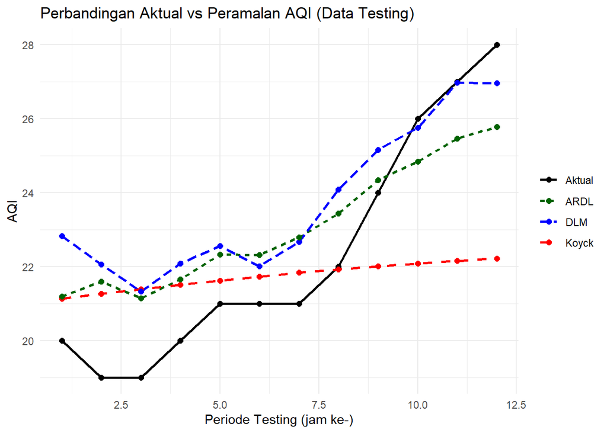

```r
plot_df <- data.frame(
  waktu   = 1:n_test,
  Aktual  = test$Yt,
  Koyck   = as.numeric(fore.koyck$forecasts),
  DLM     = as.numeric(fore.dlm.opt$forecasts),
  ARDL    = as.numeric(fore.ardl$forecasts)
)

plot_long <- reshape(plot_df, direction = "long",
                      varying = c("Aktual","Koyck","DLM","ARDL"),
                      v.names = "Nilai", timevar = "Seri",
                      times = c("Aktual","Koyck","DLM","ARDL"))

ggplot(plot_long, aes(x = waktu, y = Nilai, color = Seri, linetype = Seri)) +
  geom_line(linewidth = 1) +
  geom_point(size = 2) +
  scale_color_manual(values = c(Aktual = "black", Koyck = "red",
                                 DLM = "blue", ARDL = "darkgreen")) +
  labs(title = "Perbandingan Aktual vs Peramalan AQI (Data Testing)",
       x = "Periode Testing (jam ke-)", y = "AQI") +
  theme_minimal() +
  theme(legend.title = element_blank())
```

# Kesimpulan

- Ketiga metode (Koyck, DLM, dan ARDL) berhasil diterapkan pada data AQI dan CO New Delhi dengan lag optimum yang berbeda-beda: Koyck secara implisit meringkas seluruh lag ke dalam satu parameter $\lambda$, DLM optimum pada $q = 10$, dan ARDL optimum pada kombinasi $p = 6, q = 1$.
- Berdasarkan metrik MAPE dan deviance (SSE), model ARDL ($p = 6, q = 1$) memberikan performa peramalan terbaik pada data testing di antara ketiga model yang diuji.
- Evaluasi asumsi menunjukkan model terbaik masih belum sepenuhnya memenuhi asumsi klasik karena masih terindikasi autokorelasi pada sisaan, meskipun tidak ada indikasi heteroskedastisitas maupun penyimpangan dari normalitas.